# Work Plan

Bayes-Bats Tier 2: A Gentle Introduction to Probability and Bayesian Statistics

Authors

Laurie Baker (Bates College)

Jim Scott (Colby College)

## Overview

The aim of this project is to develop a 2-credit Gentle Introduction to Probability and Bayesian statistics course open to students across disciplines that can be taught either over the course of a semester (half of a normal course) or it could be taught during the short-term at a college (e.g. Bates, Colby, and Middlebury).

The students should be prepared to learn and code in R but the course would assume no prerequisites for probability and statistics. The idea behind the course is to expose students across disciplines to Bayesian Thinking who might be otherwise hesitant to sign up for a Bayesian course.

As part of the course we will design the syllabus to spend more time at the beginning exposing students to probability concepts and it would finish with introducing MCMC algorithms. We propose to cover the following topics:

- Overview; Setting up your computer + intro to R
- Obtaining data + basic definitions: parameter, statistic, population, sample, inference, estimation
- Probability, random variables, rules of probability, conditional probability, Bayes rule
- Discrete distributions + pmf + Exp/Var: Bernoulli, binomial, Poisson
- Likelihood + examples
- Posterior = Prior * Likelihood + examples
- A single proportion: Beta/Binomial
- Continuous distribution + pdf + Exp/Var: Normal, exponential, gamma, beta.
- A single mean (known sigma): Normal/Normal
- A single mean and sigma: Normal/Gamma
- MCMC/Gibbs

Given our backgrounds in ecology (Laurie) and epidemiology (Laurie and Jim) we will look to complement the existing course materials from Bayes Rules and Probability and Bayesian modeling to include examples and assignments from these fields. We will develop the exercises in R and host the course materials on Github and make them available for others to re-use.

## Goals

We have split our project into three phases:

### Syllabus Development

We will start by drafting a needs analysis for students entering the course. We will then review existing resources for texts, slide decks, homeworks, and labs that might be suitable for our course.

Specifically we have identified the following tasks:

- Determine software for course (RStudio, webR for materials)?
- Determine books/resources that we’ll use (for us and/or students)
- Draft a needs analysis (what background are students coming into the course with)
- Outline a syllabus, including how the course will be graded and what components we’ll use to determine grades (e.g. assignments, exams, projects, etc.)
- Formally state course objectives and learning outcomes
- Draft a course schedule.
- Finalize topics to be covered.
- Draft Homework and Activity Plan

### Activity and Homework Development

We will then focus our efforts on developing hands-on in-class activities, lab and homework assignments and case studies that will complement the existing courses and texts.

Specifically we have identified the following tasks:

- Determine activities for each class
- Determine assignments for each class
- Develop 4 new activities/assignments
- Write codebooks for the datasets used.
- Write learning objectives for each activity.
- Create a grid mapping the learning objectives across assignments

### Finalization and Submission of Activities and Syllabus

In the final phase we will incorporate feedback and update and publish our final materials (activities and syllabus) in a Github website.

Specifically we have identified the following tasks:

- Update and incorporate feedback into activities
- Develop a guide to materials for instructors.

## Timeline

Work plan

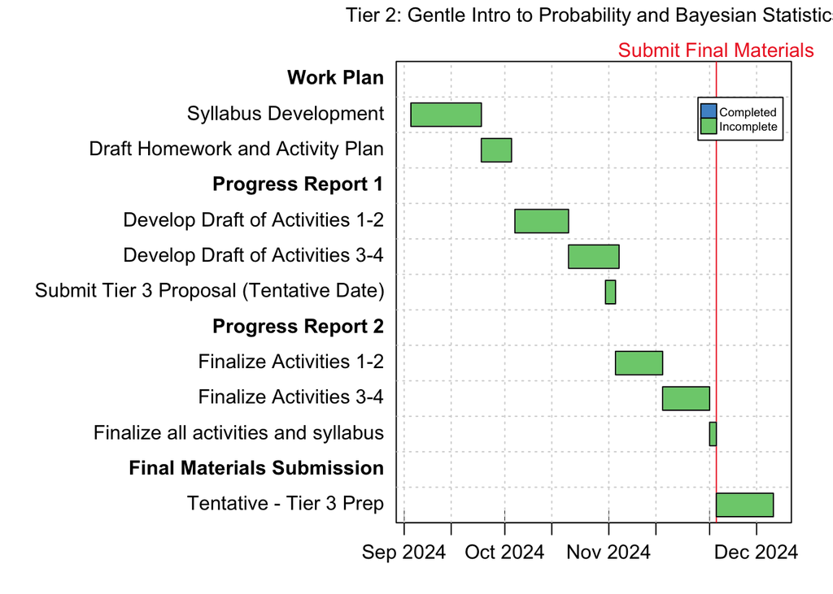

## Meeting Times

We will keep meeting based on the following:

- Weekly meetings for the activity-creating team
- Monthly meetings with mentor (Mine)
- Office hours

| Date | Time | PI | Zoom Link |
| --- | --- | --- | --- |
| 2024-09-18 | 3:30 - 4:30 pm ET | Monika |  |
| 2024-09-26 | 2:00 - 3:00 pm ET | Mine |  |
| 2024-10-07 | 3:30 - 4:30 pm ET | Monika |  |
| 2024-10-15 | 3:00 - 4:00 pm ET | Amy |  |
| 2024-10-2? |  | Mine |  |
| 2024-11-0? |  | Mine |  |
| 2024-11-12 | 3:00 - 4:00 pm ET | Amy |  |
| 2023-11-20 | 3:30 - 4:30 pm ET | Monika |  |

## Acknowledgements

This report template comes from Zachary Del Rosario and Stefani Langehennig’s [Bayes-Bats tier 2 project](https://github.com/bayes-bats/tier2-freq-bayes)